# Structure and Function of the Soil Microbiome Underlying N<sub>2</sub>O Emissions from Global Wetlands

Mohammad Bahram<sup>1,2,9</sup>, Mikk Espenberg<sup>1,9</sup>, Jaan Pärn<sup>1,9</sup>, Laura Lehtovirta-Morley<sup>3</sup>, Sten Anslan<sup>1</sup>, Kuno Kasak<sup>1</sup>, Urmas Kõljalg<sup>1</sup>, Jaan Liira<sup>1</sup>, Martin Maddison<sup>1</sup>, Mari Moora<sup>1</sup>, Ülo Niinemets<sup>4</sup>, Maarja Öpik<sup>1</sup>, Meelis Pärtel<sup>1</sup>, Kaido Soosaar<sup>1</sup>, Martin Zobel<sup>1</sup>, Falk Hildebrand<sup>5,6</sup>, Leho Tedersoo<sup>7,8,9</sup>, Ülo Mander<sup>1,9</sup>

1. **Institute of Ecology and Earth Sciences**, University of Tartu, Tartu, Estonia.
2. **Department of Ecology**, Swedish University of Agricultural Sciences, Uppsala, Sweden.
3. **School of Biological Sciences**, University of East Anglia, Norwich, UK.
4. **Institute of Agricultural & Environmental Sciences**, Estonian University of Life Sciences, Tartu, Estonia.
5. **Quadram Institute Bioscience**, Norwich, Norfolk, UK.
6. **Digital Biology**, Earlham Institute, Norwich, Norfolk, UK.
7. **College of Science**, King Saud University, Riyadh, Saudi Arabia.
8. **Mycology and Microbiology Center**, University of Tartu, Tartu, Estonia.
9. **These authors contributed equally**: Mohammad Bahram, Mikk Espenberg, Jaan Pärn, Leho Tedersoo, Ülo Mander.

## 0.1 Abstract

Wetland soils are the greatest source of nitrous oxide (N<sub>2</sub>O), a critical greenhouse gas and ozone depleter released by microbes. Yet, microbial players and processes underlying the N<sub>2</sub>O emissions from wetland soils are poorly understood. Using in situ N<sub>2</sub>O measurements and by determining the structure and potential functional of microbial communities in 645 wetland soil samples globally, we examined the potential role of archaea, bacteria, and fungi in nitrogen (N) cycling and N<sub>2</sub>O emissions. We show that N<sub>2</sub>O emissions are higher in drained and warm wetland soils, and are correlated with functional diversity of microbes. We further provide evidence that despite their much lower abundance compared to bacteria, nitrifying archaeal abundance is a key factor explaining N<sub>2</sub>O emissions from wetland soils globally. Our data suggest that ongoing global warming and intensifying environmental change may boost archaeal nitrifiers, collectively transforming wetland soils to a greater source of N<sub>2</sub>O.

## 0.2 Introduction

- Wetland soils, covering only **8%** of the terrestrial Earth surface, store some of the largest organic carbon (C) stocks.
  - Microbial degradation of C and nitrogen (N) stocks can release **greenhouse gases (GHGs)** like nitrous oxide (N₂O).
  - **N₂O** is a potent GHG with a global warming potential **265 times** that of CO₂ and is the most significant ozone-depleting substance.
- Wetland soils face **land-use changes** such as:
  - **Afforestation** and conversion to agricultural land, typically preceded by drainage.
  - These changes have long-term consequences for **N₂O emissions**.
- Key microbial processes contributing to **N₂O production** include:
  - **Classical denitrification**, **nitrifier denitrification**, and **dissimilatory nitrate reduction to ammonia (DNRA)**, which occur primarily under anoxic conditions.
  - **Ammonia oxidation**, the first step in nitrification, is an aerobic process performed by Ammonia oxidizing bacteria (AOB), Ammonia oxidizing archaea (AOA), Complete ammonia oxidizers (comammox Nitrospira).
- **Ammonia oxidizing archaea (AOA)**:
  - Directly produce N₂O and provide substrate for denitrification.
  - Likely play a pivotal, underexplored role in fueling denitrification and facilitating terrestrial **N₂O emissions**.
- Analysis of **645 wetland soils** using:
  - Functional metagenomics to estimate relative abundance of N-cycle genes without PCR biases.
  - Multi-group metabarcoding of bacterial, archaeal, and fungal genes.
  - Absolute quantification of N-cycle gene abundances.
  - In situ N₂O flux and ex situ potential N₂ productio analyses.
  - Genomic data used to understand genetic mechanisms underlying N₂O production.
- Hypotheses:
  - High **N₂O production** in global wetland soils is primarily related to the **diversity and abundance of nitrifying microbes**.
  - **Archaeal nitrifiers**, in both absolute and relative abundance to denitrifiers, are the most robust explanatory factor for **N₂O emissions** globally.

## 0.3 Results and discussion

### 0.3.1 **Global Patterns of N2O Fluxes**

- Soil temperature and land use impact N2O emissions: Warmer soils and intensive land use increase N2O release from wetland soils.
- Emissions increase with temperature: N2O emissions are exponentially related to the temperature of the warmest month.
- Land use type is a key factor: Bare soils have the highest N2O emissions, while forest soils have the lowest.
- Latitude affects emissions: N2O emissions decrease as latitudes increase, with stronger emissions closer to the equator.
- N2 production: The production of N2 (another nitrogen gas) is highest in temperate climates and negatively correlated with land-use intensity.

```r
library(readxl)
```

```r
library(ggplot2)
library(maps)
library(dplyr)
# data and world map
data_1a <- read_excel("D:/hpliu/Mikk_dataset/Source_data.xlsx", sheet = "Fig.1a")
head(data_1a)
```

```
## # A tibble: 6 × 7
##   ...1  `AamoA/nir`    N2O Latitude Longitude Land_use ...7
##   <chr>       <dbl>  <dbl>    <dbl>     <dbl> <chr>    <chr>
## 1 Y001        0.309 -0.371     64.3     -15.5 Fen      <NA>
## 2 Y002        0.248 -1.51      64.3     -15.5 Fen      <NA>
## 3 Y003        0.262  1.49      64.3     -15.5 Fen      <NA>
## 4 Y004        0.264  0         64.3     -15.5 Fen      <NA>
## 5 Y005        0.315 -3.48      64.3     -15.5 Pasture  <NA>
## 6 Y006        0.285  0         64.3     -15.5 Pasture  <NA>
```

```r
world_map <- map_data("world")

datav2 <- data_1a %>%
  mutate(N2O_scale = case_when(
    `N2O` >= -10 & `N2O` <= 10 ~ 1,
    `N2O` > 10 & `N2O` <= 100 ~ 5,
    `N2O` > 100 & `N2O` <= 500 ~ 8,
    TRUE ~ 10
  ))
head(datav2)
```

```
## # A tibble: 6 × 8
##   ...1  `AamoA/nir`    N2O Latitude Longitude Land_use ...7  N2O_scale
##   <chr>       <dbl>  <dbl>    <dbl>     <dbl> <chr>    <chr>     <dbl>
## 1 Y001        0.309 -0.371     64.3     -15.5 Fen      <NA>          1
## 2 Y002        0.248 -1.51      64.3     -15.5 Fen      <NA>          1
## 3 Y003        0.262  1.49      64.3     -15.5 Fen      <NA>          1
## 4 Y004        0.264  0         64.3     -15.5 Fen      <NA>          1
## 5 Y005        0.315 -3.48      64.3     -15.5 Pasture  <NA>          1
## 6 Y006        0.285  0         64.3     -15.5 Pasture  <NA>          1
```

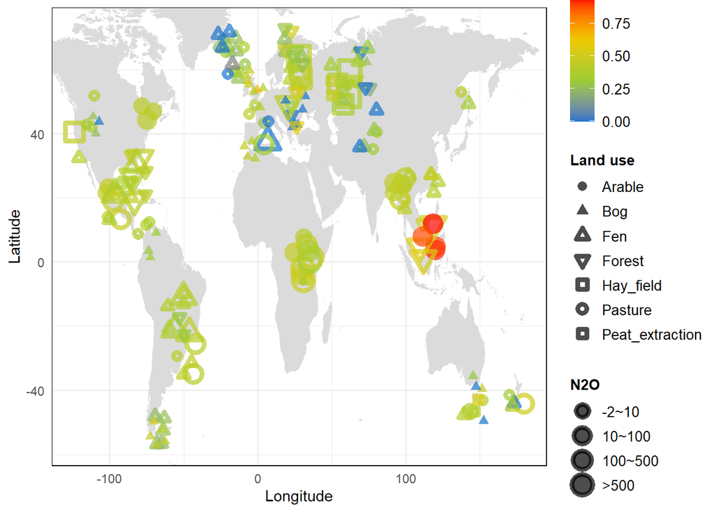

```r
# Plot
plot_a <- ggplot() +
  geom_map(data = world_map, map = world_map,
           aes(map_id = region),
           fill = "gray86", size = 0.5) +
  geom_point(data = datav2,
             position = position_jitter(h = 7, w = 7), #automatically disperse
             aes(x = Longitude, y = Latitude, shape = datav2$Land_use, color = datav2$`AamoA/nir`, size = datav2$N2O_scale),
             alpha = 0.7, stroke = 2.5 #stroke:thicker edges
  ) +
  scale_shape_manual(values = c(16, 17, 2, 6, 0, 21, 22, 23)) +
  scale_color_gradientn(colors = c("#1874CD", "olivedrab3", "#EEC900","red"))+
  scale_size_continuous(range = c(2, 8)) +  # This keeps the original size scale
  scale_size_continuous(
    breaks = c(2, 4, 6, 8),  # Use breaks to control which values to display in the legend
    labels = c("-2~10", "10~100", "100~500", ">500")  # Change the legend labels
  ) +
  theme_minimal() +
  labs(
    x = "Longitude", y = "Latitude",
    color = "AamoA/nir",  # Change the color legend title
    shape = "Land use",    # Change the shape legend title
    size = "N2O"           # Change the size legend title
  ) +
  theme(legend.position = "right",
        legend.title = element_text(size = 10, face = "bold"),  # Change legend title size and font
        legend.text = element_text(size = 10),
        panel.border = element_rect(color = "black", fill = NA, size = 0.5))  # legend
plot(plot_a)
```

**Fig.1 istribution of the study sites and their measured N2O emissions as well as the archaeal-nitrifier/denitrifier ratio (archaeal amoA/(nirK + nirS))**

### 0.3.2 **Relationships of Global N2O Fluxes to Microbial Diversity and Taxa**

- Microbial diversity varies with latitude: Archaeal diversity increases toward the equator, while bacterial diversity is highest in mid-latitudes.
- Soil variables affect microbial diversity: Climate and soil conditions (like pH, C/N ratio) greatly influence microbial diversity.
- Archaeal diversity linked to N2O emissions: The presence of archaea (specifically AOA from Thaumarchaeota) correlates strongly with N2O emissions.
- Key microbial groups: The most abundant phyla in global wetlands are Proteobacteria, Acidobacteriota, and Chloroflexi, but they aren’t strongly related to N2O emissions.
- Functional microbes linked to N2O: Specific archaeal groups (like Nitrosotenuis and Nitrosocosmicus) are more strongly associated with N2O fluxes.

```r
#data
data_1b <- read_excel("D:/hpliu/Mikk_dataset/Source_data.xlsx", sheet = "Fig1b-d")
head(data_1b)
```

```
## # A tibble: 6 × 6
##   ...1  Site                  Latitude    N2O Archaeal_amoA         nir
##   <chr> <chr>                    <dbl>  <dbl>         <dbl>       <dbl>
## 1 Y001  Iceland_fen_1             64.3 -0.371       402159. 4500024495.
## 2 Y002  Iceland_fen_1             64.3 -1.51         15743. 1193072309.
## 3 Y003  Iceland_fen_1             64.3  1.49         49635. 3633016615.
## 4 Y004  Iceland_fen_1             64.3  0            87676. 8526838441.
## 5 Y005  Iceland_drained_fen_2     64.3 -3.48        415234. 9776754909.
## 6 Y006  Iceland_drained_fen_2     64.3  0            48674. 1113960206.
```

```r
data_1bv2 <- data_1b  %>%
  mutate(LogN2O = log10(15 + N2O)) # calculate
head(data_1bv2)
```

```
## # A tibble: 6 × 7
##   ...1  Site                  Latitude    N2O Archaeal_amoA         nir LogN2O
##   <chr> <chr>                    <dbl>  <dbl>         <dbl>       <dbl>  <dbl>
## 1 Y001  Iceland_fen_1             64.3 -0.371       402159. 4500024495.   1.17
## 2 Y002  Iceland_fen_1             64.3 -1.51         15743. 1193072309.   1.13
## 3 Y003  Iceland_fen_1             64.3  1.49         49635. 3633016615.   1.22
## 4 Y004  Iceland_fen_1             64.3  0            87676. 8526838441.   1.18
## 5 Y005  Iceland_drained_fen_2     64.3 -3.48        415234. 9776754909.   1.06
## 6 Y006  Iceland_drained_fen_2     64.3  0            48674. 1113960206.   1.18
```

```r
# standard error (SE)
data_1bv3 <- data_1bv2 %>%
  group_by(Latitude) %>%
  summarise(
    mean_LogN2O = mean(LogN2O, na.rm = TRUE),
    se_LogN2O = sd(LogN2O, na.rm = TRUE) / sqrt(n())
  )
summary(data_1bv3)
```

```
##     Latitude        mean_LogN2O      se_LogN2O
##  Min.   : 0.9337   Min.   :1.113   Min.   :0.000000
##  1st Qu.:20.6108   1st Qu.:1.175   1st Qu.:0.005311
##  Median :38.0169   Median :1.250   Median :0.020408
##  Mean   :34.2176   Mean   :1.454   Mean   :0.094612
##  3rd Qu.:48.4935   3rd Qu.:1.630   3rd Qu.:0.108679
##  Max.   :67.9978   Max.   :2.847   Max.   :1.075233
##                                    NA's   :21
```

```r
data_1bv4 <- lm(mean_LogN2O ~ Latitude, data = data_1bv3)
data_1bv4
```

```
##
## Call:
## lm(formula = mean_LogN2O ~ Latitude, data = data_1bv3)
##
## Coefficients:
## (Intercept)     Latitude
##     1.84105     -0.01132
```

```r
summary(data_1bv4)
```

```
##
## Call:
## lm(formula = mean_LogN2O ~ Latitude, data = data_1bv3)
##
## Residuals:
##     Min      1Q  Median      3Q     Max
## -0.6079 -0.1880 -0.0642  0.1485  1.0191
##
## Coefficients:
##              Estimate Std. Error t value Pr(>|t|)
## (Intercept)  1.841055   0.080894   22.76  < 2e-16 ***
## Latitude    -0.011324   0.002059   -5.50 5.64e-07 ***
## ---
## Signif. codes:  0 '***' 0.001 '**' 0.01 '*' 0.05 '.' 0.1 ' ' 1
##
## Residual standard error: 0.3398 on 71 degrees of freedom
## Multiple R-squared:  0.2988, Adjusted R-squared:  0.2889
## F-statistic: 30.26 on 1 and 71 DF,  p-value: 5.642e-07
```

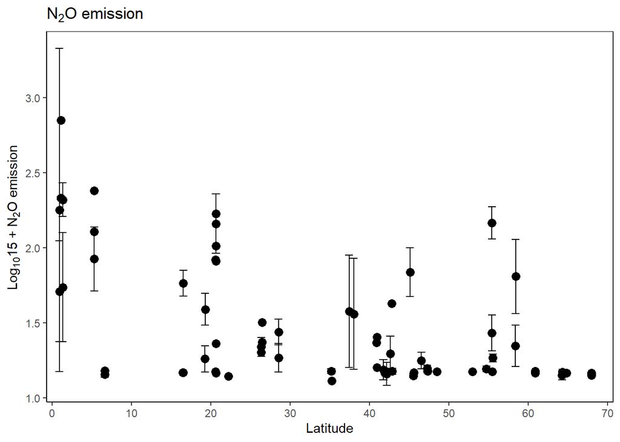

```r
r_squared <- summary(data_1bv4)$r


# Plot
pcPlot_b<- ggplot(data_1bv3, aes(x = Latitude, y = mean_LogN2O)) +
  geom_point(color = "black", size = 3) +  # Scatter plot for means
  geom_errorbar(aes(ymin = mean_LogN2O - se_LogN2O, ymax = mean_LogN2O + se_LogN2O),
                width = 1, color = "black") +  # Error bars
  labs(
    x = "Latitude",
    y = expression("Log"[10] * "15 + N"[2] * "O emission"),
    title = expression("N"[2] * "O emission")
  ) +
  theme_classic() +
  theme(
    panel.border = element_rect(color = "black", fill = NA, size = 0.5)
  )+
  scale_x_continuous(
    limits = c(0, 70),
    breaks = seq(0, 70, 10),
    expand = c(0.01, 0.01)
    )
pcPlot_b
```

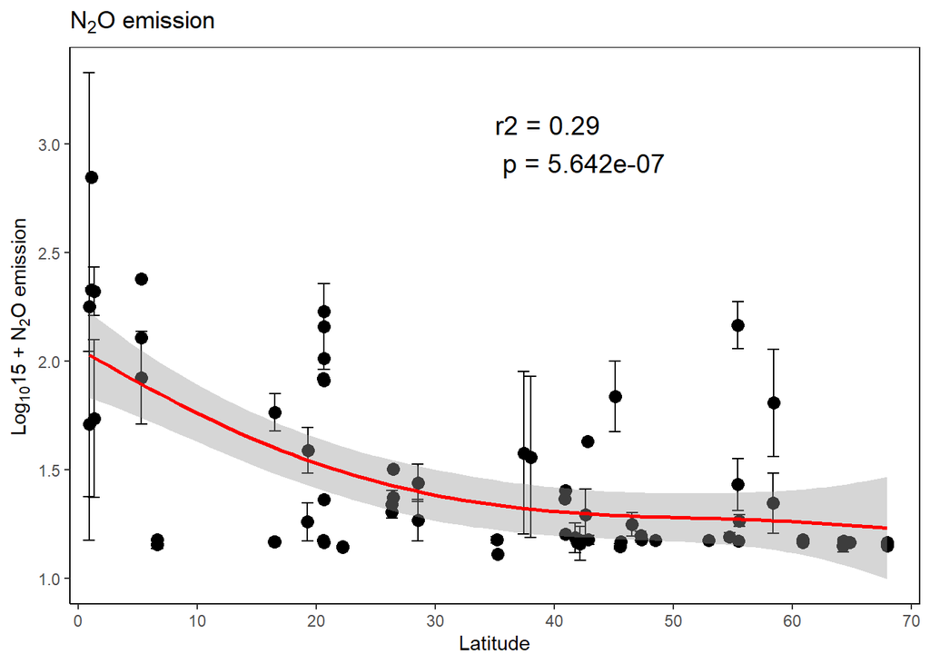

```r
plot_b <- pcPlot_b+
  stat_smooth(method="gam", color = "red")+
  annotate("text",
           x = 35, y = 3,
           label = paste("r2 = 0.29", "\n p = 5.642e-07"),
           size = 5, color = "black", hjust = 0)
plot_b
```

```r
#c
#data
data_1c <- read_excel("D:/hpliu/Mikk_dataset/Source_data.xlsx", sheet = "Fig1b-d")
head(data_1c)
```

```
## # A tibble: 6 × 6
##   ...1  Site                  Latitude    N2O Archaeal_amoA         nir
##   <chr> <chr>                    <dbl>  <dbl>         <dbl>       <dbl>
## 1 Y001  Iceland_fen_1             64.3 -0.371       402159. 4500024495.
## 2 Y002  Iceland_fen_1             64.3 -1.51         15743. 1193072309.
## 3 Y003  Iceland_fen_1             64.3  1.49         49635. 3633016615.
## 4 Y004  Iceland_fen_1             64.3  0            87676. 8526838441.
## 5 Y005  Iceland_drained_fen_2     64.3 -3.48        415234. 9776754909.
## 6 Y006  Iceland_drained_fen_2     64.3  0            48674. 1113960206.
```

```r
data_1cv2 <- data_1c  %>%
  mutate(LogN2OA = log10(15 + Archaeal_amoA)) # calculate
head(data_1cv2)
```

```
## # A tibble: 6 × 7
##   ...1  Site                  Latitude    N2O Archaeal_amoA         nir LogN2OA
##   <chr> <chr>                    <dbl>  <dbl>         <dbl>       <dbl>   <dbl>
## 1 Y001  Iceland_fen_1             64.3 -0.371       402159. 4500024495.    5.60
## 2 Y002  Iceland_fen_1             64.3 -1.51         15743. 1193072309.    4.20
## 3 Y003  Iceland_fen_1             64.3  1.49         49635. 3633016615.    4.70
## 4 Y004  Iceland_fen_1             64.3  0            87676. 8526838441.    4.94
## 5 Y005  Iceland_drained_fen_2     64.3 -3.48        415234. 9776754909.    5.62
## 6 Y006  Iceland_drained_fen_2     64.3  0            48674. 1113960206.    4.69
```

```r
# standard error (SE)
data_1cv3 <- data_1cv2 %>%
  group_by(Latitude) %>%
  summarise(
    mean_LogN2OA = mean(LogN2OA, na.rm = TRUE),
    se_LogN2OA = sd(LogN2OA, na.rm = TRUE) / sqrt(n())
  )
summary(data_1cv3)
```

```
##     Latitude        mean_LogN2OA     se_LogN2OA
##  Min.   : 0.9337   Min.   :1.176   Min.   :0.01018
##  1st Qu.:20.6108   1st Qu.:5.705   1st Qu.:0.11726
##  Median :38.0169   Median :7.011   Median :0.25109
##  Mean   :34.2176   Mean   :6.478   Mean   :0.44104
##  3rd Qu.:48.4935   3rd Qu.:7.953   3rd Qu.:0.48991
##  Max.   :67.9978   Max.   :8.763   Max.   :3.41032
##                                    NA's   :21
```

```r
data_1cv4 <- lm(mean_LogN2OA ~ Latitude, data = data_1cv3)
data_1cv4
```

```
##
## Call:
## lm(formula = mean_LogN2OA ~ Latitude, data = data_1cv3)
##
## Coefficients:
## (Intercept)     Latitude
##     7.97054     -0.04363
```

```r
summary(data_1cv4)
```

```
##
## Call:
## lm(formula = mean_LogN2OA ~ Latitude, data = data_1cv3)
##
## Residuals:
##     Min      1Q  Median      3Q     Max
## -4.9270 -0.8265  0.2265  1.1263  2.5834
##
## Coefficients:
##             Estimate Std. Error t value Pr(>|t|)
## (Intercept)  7.97054    0.38036  20.955  < 2e-16 ***
## Latitude    -0.04363    0.00968  -4.507 2.53e-05 ***
## ---
## Signif. codes:  0 '***' 0.001 '**' 0.01 '*' 0.05 '.' 0.1 ' ' 1
##
## Residual standard error: 1.598 on 71 degrees of freedom
## Multiple R-squared:  0.2225, Adjusted R-squared:  0.2115
## F-statistic: 20.31 on 1 and 71 DF,  p-value: 2.528e-05
```

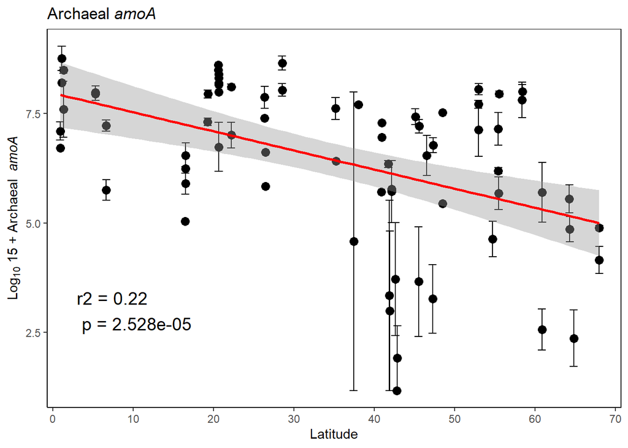

```r
# Plot
pcPlot_c <- ggplot(data_1cv3, aes(x = Latitude, y = mean_LogN2OA)) +
  geom_point(color = "black", size = 3) +  # Scatter plot for means
  geom_errorbar(aes(ymin = mean_LogN2OA - se_LogN2OA, ymax = mean_LogN2OA + se_LogN2OA),
                width = 1, color = "black") +  # Error bars
  labs(
    x = "Latitude",
    y = expression("Log"[10] * " 15 + Archaeal " * italic(" amoA")),
    title =  expression("Archaeal "* italic("amoA"))
  ) +
  theme_classic() +
  theme(
    panel.border = element_rect(color = "black", fill = NA, size = 0.5)
  )+
  scale_x_continuous(
    limits = c(0, 70),
    breaks = seq(0, 70, 10),
    expand = c(0.01, 0.01)
  )
plot_c <- pcPlot_c+
  stat_smooth(method="lm", color = "red")+
  annotate("text",
           x = 3, y = 3,
           label = paste("r2 = 0.22", "\n p = 2.528e-05"),
           size = 5, color = "black", hjust = 0)
plot_c
```

```r
#d
#data
data_1d <- read_excel("D:/hpliu/Mikk_dataset/Source_data.xlsx", sheet = "Fig1b-d")
head(data_1d)
```

```
## # A tibble: 6 × 6
##   ...1  Site                  Latitude    N2O Archaeal_amoA         nir
##   <chr> <chr>                    <dbl>  <dbl>         <dbl>       <dbl>
## 1 Y001  Iceland_fen_1             64.3 -0.371       402159. 4500024495.
## 2 Y002  Iceland_fen_1             64.3 -1.51         15743. 1193072309.
## 3 Y003  Iceland_fen_1             64.3  1.49         49635. 3633016615.
## 4 Y004  Iceland_fen_1             64.3  0            87676. 8526838441.
## 5 Y005  Iceland_drained_fen_2     64.3 -3.48        415234. 9776754909.
## 6 Y006  Iceland_drained_fen_2     64.3  0            48674. 1113960206.
```

```r
data_1dv2 <- data_1d  %>%
  mutate(LogN2On = log10(15 + nir)) # calculate
head(data_1dv2)
```

```
## # A tibble: 6 × 7
##   ...1  Site                  Latitude    N2O Archaeal_amoA         nir LogN2On
##   <chr> <chr>                    <dbl>  <dbl>         <dbl>       <dbl>   <dbl>
## 1 Y001  Iceland_fen_1             64.3 -0.371       402159. 4500024495.    9.65
## 2 Y002  Iceland_fen_1             64.3 -1.51         15743. 1193072309.    9.08
## 3 Y003  Iceland_fen_1             64.3  1.49         49635. 3633016615.    9.56
## 4 Y004  Iceland_fen_1             64.3  0            87676. 8526838441.    9.93
## 5 Y005  Iceland_drained_fen_2     64.3 -3.48        415234. 9776754909.    9.99
## 6 Y006  Iceland_drained_fen_2     64.3  0            48674. 1113960206.    9.05
```

```r
# standard error (SE)
data_1dv3 <- data_1dv2 %>%
  group_by(Latitude) %>%
  summarise(
    mean_LogN2On = mean(LogN2On, na.rm = TRUE),
    se_LogN2On = sd(LogN2On, na.rm = TRUE) / sqrt(n())
  )
summary(data_1dv3)
```

```
##     Latitude        mean_LogN2On      se_LogN2On
##  Min.   : 0.9337   Min.   : 7.079   Min.   :0.005592
##  1st Qu.:20.6108   1st Qu.: 9.118   1st Qu.:0.063771
##  Median :38.0169   Median : 9.552   Median :0.110340
##  Mean   :34.2176   Mean   : 9.479   Mean   :0.152640
##  3rd Qu.:48.4935   3rd Qu.:10.038   3rd Qu.:0.207970
##  Max.   :67.9978   Max.   :11.074   Max.   :0.953328
##                                     NA's   :21
```

```r
data_1dv4 <- lm(mean_LogN2On ~ Latitude, data = data_1dv3)
data_1dv4
```

```
##
## Call:
## lm(formula = mean_LogN2On ~ Latitude, data = data_1dv3)
##
## Coefficients:
## (Intercept)     Latitude
##   9.4575131    0.0006176
```

```r
summary(data_1dv4)
```

```
##
## Call:
## lm(formula = mean_LogN2On ~ Latitude, data = data_1dv3)
##
## Residuals:
##      Min       1Q   Median       3Q      Max
## -2.40454 -0.34804  0.06402  0.58011  1.58960
##
## Coefficients:
##              Estimate Std. Error t value Pr(>|t|)
## (Intercept) 9.4575131  0.1788228  52.888   <2e-16 ***
## Latitude    0.0006176  0.0045510   0.136    0.892
## ---
## Signif. codes:  0 '***' 0.001 '**' 0.01 '*' 0.05 '.' 0.1 ' ' 1
##
## Residual standard error: 0.7511 on 71 degrees of freedom
## Multiple R-squared:  0.0002593,  Adjusted R-squared:  -0.01382
## F-statistic: 0.01841 on 1 and 71 DF,  p-value: 0.8924
```

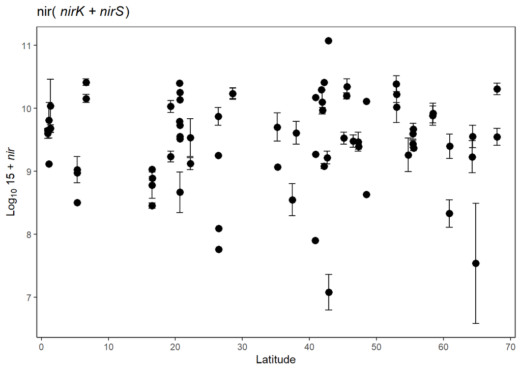

```r
r2_value_1 <- summary(data_1dv4)$r.squared



# Plot
pcPlot_d <- ggplot(data_1dv3, aes(x = Latitude, y = mean_LogN2On)) +
  geom_point(color = "black", size = 3) +  # Scatter plot for means
  geom_errorbar(aes(ymin = mean_LogN2On - se_LogN2On, ymax = mean_LogN2On + se_LogN2On),
                width = 1, color = "black") +  # Error bars
  labs(
    x = "Latitude",
    y = expression("Log"[10] * " 15 + " * italic("nir")),
    title =  expression("nir( "* italic("nirK + nirS")*")")
  ) +
  theme_classic() +
  theme(
    panel.border = element_rect(color = "black", fill = NA, size = 0.5)
  )+
  scale_x_continuous(
    limits = c(0, 70),
    breaks = seq(0, 70, 10),
    expand = c(0.01, 0.01)
  )
pcPlot_d
```

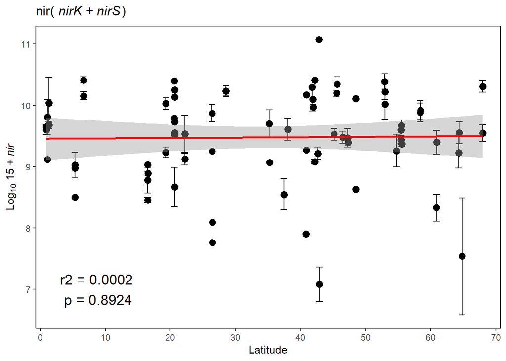

```r
plot_d <-pcPlot_d +
  stat_smooth(method="lm", color = "red")+
  annotate("text",
           x = 3, y = 7,
           label = paste("r2 = 0.0002", "\n p = 0.8924"),
           size = 5, color = "black", hjust = 0)
plot_d
```

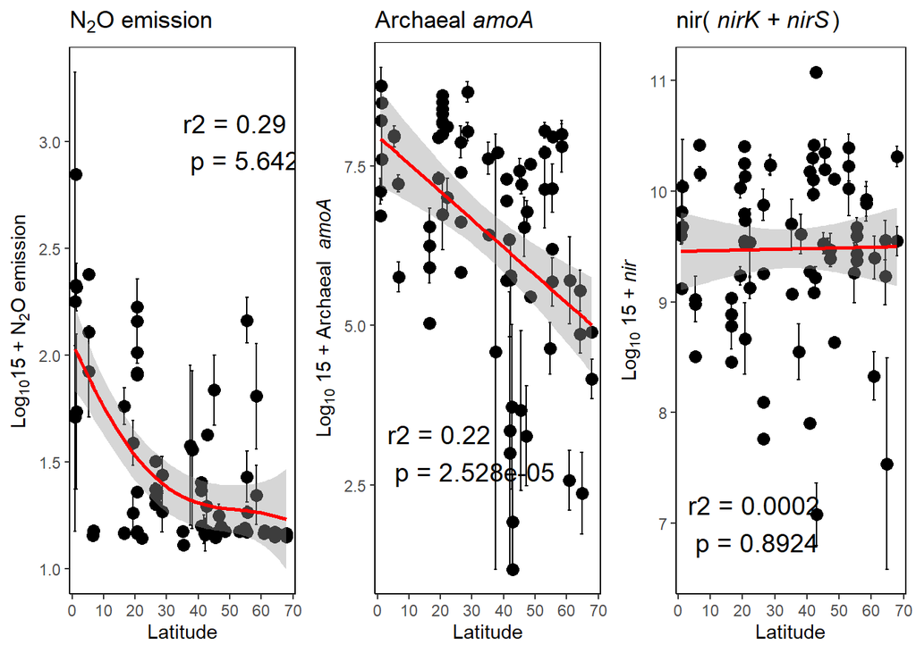

```r
#combine
library(cowplot)
combined_plot<-plot_grid(plot_b, plot_c, plot_d,
          ncol = 3,
          nrow = 1,
          rel_widths = c(1, 1, 1)
          )
plot(combined_plot)
```

**Fig.2 atitudinal gradient of N2O emissions, archaeal amoA and nir (nirK+nirS)**

### 0.3.3 **Metagenomic Analysis of Pathways Underlying Global N2O Fluxes**

- Key genes involved in N2O production: Archaeal amoA gene (linked to ammonia oxidation) strongly correlates with N2O emission.
- Ammonia oxidation pathway: Thaumarchaeota, including Nitrososphaera and Nitrosocosmicus, are crucial for ammonia oxidation and N2O emission.
- Genomic analysis supports findings: A comparison of archaeal genomes shows that ammonia-oxidizing archaea are more abundant than bacteria in wetland soils.

### 0.3.4 **Functional Genes Driving Global N2O Fluxes**

```r
library(corrplot)
library(reshape)
library(RColorBrewer)

data_4 <- read_excel("D:/hpliu/Mikk_dataset/Source_data.xlsx", sheet = "Fig4a")
head(data_4)
```

```
## # A tibble: 6 × 19
##   ...1          N2O Latitude pH    VPG     OrM Water_content    NO3    NH4 `C/N`
##   <chr>       <dbl>    <dbl> <chr> <chr> <dbl>         <dbl>  <dbl>  <dbl> <chr>
## 1 Bashkortos…  1.27    55.5  6.75… 5     0.29          0.351 0.876  -0.595 1.10…
## 2 Bashkortos…  1.47    55.4  4.45… 5     0.342         0.209 1.11    1.50  NA
## 3 Bashkortos…  2.19    55.4  3.82… 5     0.29          0.418 1.01    1.06  1.06…
## 4 Bashkortos…  1.17    55.5  6.14… 1     0.507         0.93  0.0780  1.66  1.24…
## 5 Borneo_dra…  2.43     5.32 2.16… 4.75  0.784         0.384 1.15    1.69  1.46…
## 6 Borneo_swa…  1.95     5.32 2.30… 5     0.793         0.610 1.50    1.66  1.35…
## # ℹ 9 more variables: Water_table <chr>, MAT <dbl>, MAP <dbl>, nirK <dbl>,
## #   nirS <dbl>, nosZI <dbl>, nosZII <dbl>, Bacterial_amoA <dbl>,
## #   Archaeal_amoA <dbl>
```

```r
numeric_data <- data_4 %>% select(where(is.numeric))
M<-cor(numeric_data)
head(round(M,2))
```

```
##                 N2O Latitude   OrM Water_content   NO3   NH4   MAT   MAP  nirK
## N2O            1.00    -0.48 -0.07         -0.26  0.45  0.14  0.37  0.19  0.02
## Latitude      -0.48     1.00  0.36          0.08 -0.25 -0.17 -0.81 -0.55 -0.02
## OrM           -0.07     0.36  1.00          0.14  0.10  0.09 -0.47 -0.15  0.24
## Water_content -0.26     0.08  0.14          1.00 -0.46  0.19 -0.12  0.00  0.13
## NO3            0.45    -0.25  0.10         -0.46  1.00 -0.01  0.19  0.11  0.15
## NH4            0.14    -0.17  0.09          0.19 -0.01  1.00  0.08  0.18  0.13
##                nirS nosZI nosZII Bacterial_amoA Archaeal_amoA
## N2O            0.12  0.09   0.26           0.13          0.37
## Latitude      -0.26 -0.18  -0.29           0.20         -0.43
## OrM           -0.41  0.00  -0.32           0.02         -0.35
## Water_content -0.08  0.05  -0.14          -0.20         -0.29
## NO3            0.25  0.15   0.28           0.43          0.40
## NH4            0.00  0.20   0.08          -0.06         -0.05
```

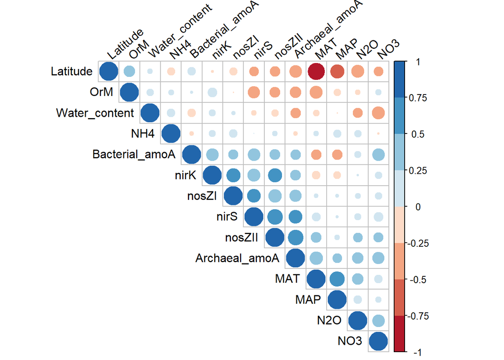

```r
corrplot(M, type="upper", order="hclust", tl.col="black", tl.srt=40,
         col=brewer.pal(n=8, name="RdBu"))
```

### 0.3.5 **Environmental Determinants of N2O-Related Microbial Communities**

- Soil temperature impacts AOA: Archaeal amoA activity peaks around 20°C, suggesting that warmer soil temperatures can enhance N2O emissions through increased AOA abundance.
- AOA/AOB ratio: A higher ratio of AOA to AOB (ammonia-oxidizing bacteria) is positively correlated with soil temperature.

```r
data_1 <- read_excel("D:/hpliu/Mikk_dataset/Source_data.xlsx", sheet = "EDFig.1")
head(data_1)
```

```
## # A tibble: 6 × 8
##   ...1  Site          N2O Max_temperature_of_w…¹ Agricultural_intensity Land_use
##   <chr> <chr>       <dbl>                  <dbl>                  <dbl> <chr>
## 1 Y001  Iceland_f… -0.371                   11.2                      1 fen
## 2 Y002  Iceland_f… -1.51                    11.2                      1 fen
## 3 Y003  Iceland_f…  1.49                    11.2                      1 fen
## 4 Y004  Iceland_f…  0                       11.2                      1 fen
## 5 Y005  Iceland_d… -3.48                    11.8                      1 pasture
## 6 Y006  Iceland_d…  0                       11.8                      1 pasture
## # ℹ abbreviated name: ¹Max_temperature_of_warmest_month
## # ℹ 2 more variables: Longitude <dbl>, Latitude <dbl>
```

```r
data_1v21 <- data_1  %>%
  mutate(Biome_type = ifelse(data_1$Latitude >= -23.5 & data_1$Latitude <= 23.5, "Tropical", "Non-Tropical"))
head(data_1v21)
```

```
## # A tibble: 6 × 9
##   ...1  Site          N2O Max_temperature_of_w…¹ Agricultural_intensity Land_use
##   <chr> <chr>       <dbl>                  <dbl>                  <dbl> <chr>
## 1 Y001  Iceland_f… -0.371                   11.2                      1 fen
## 2 Y002  Iceland_f… -1.51                    11.2                      1 fen
## 3 Y003  Iceland_f…  1.49                    11.2                      1 fen
## 4 Y004  Iceland_f…  0                       11.2                      1 fen
## 5 Y005  Iceland_d… -3.48                    11.8                      1 pasture
## 6 Y006  Iceland_d…  0                       11.8                      1 pasture
## # ℹ abbreviated name: ¹Max_temperature_of_warmest_month
## # ℹ 3 more variables: Longitude <dbl>, Latitude <dbl>, Biome_type <chr>
```

```r
data_1v2 <- data_1v21  %>%
  mutate(LogN2Oe = log10(15 + N2O)) # calculate
head(data_1v2)
```

```
## # A tibble: 6 × 10
##   ...1  Site          N2O Max_temperature_of_w…¹ Agricultural_intensity Land_use
##   <chr> <chr>       <dbl>                  <dbl>                  <dbl> <chr>
## 1 Y001  Iceland_f… -0.371                   11.2                      1 fen
## 2 Y002  Iceland_f… -1.51                    11.2                      1 fen
## 3 Y003  Iceland_f…  1.49                    11.2                      1 fen
## 4 Y004  Iceland_f…  0                       11.2                      1 fen
## 5 Y005  Iceland_d… -3.48                    11.8                      1 pasture
## 6 Y006  Iceland_d…  0                       11.8                      1 pasture
## # ℹ abbreviated name: ¹Max_temperature_of_warmest_month
## # ℹ 4 more variables: Longitude <dbl>, Latitude <dbl>, Biome_type <chr>,
## #   LogN2Oe <dbl>
```

```r
data_1v2
```

```
## # A tibble: 196 × 10
##    ...1  Site         N2O Max_temperature_of_w…¹ Agricultural_intensity Land_use
##    <chr> <chr>      <dbl>                  <dbl>                  <dbl> <chr>
##  1 Y001  Iceland_… -0.371                   11.2                      1 fen
##  2 Y002  Iceland_… -1.51                    11.2                      1 fen
##  3 Y003  Iceland_…  1.49                    11.2                      1 fen
##  4 Y004  Iceland_…  0                       11.2                      1 fen
##  5 Y005  Iceland_… -3.48                    11.8                      1 pasture
##  6 Y006  Iceland_…  0                       11.8                      1 pasture
##  7 Y007  Iceland_…  0.564                   11.8                      1 pasture
##  8 Y008  Iceland_…  0                       11.8                      1 pasture
##  9 Y009  Iceland_… -0.947                   12.6                      1 pasture
## 10 Y010  Iceland_…  0                       12.6                      1 pasture
## # ℹ 186 more rows
## # ℹ abbreviated name: ¹Max_temperature_of_warmest_month
## # ℹ 4 more variables: Longitude <dbl>, Latitude <dbl>, Biome_type <chr>,
## #   LogN2Oe <dbl>
```

```r
# standard error (SE)
data_1v3 <- data_1v2 %>%
  group_by(Latitude) %>%
  summarise(
    mean_LogN2Oe = mean(LogN2Oe, na.rm = TRUE),
    se_LogN2Oe = sd(LogN2Oe, na.rm = TRUE) / sqrt(n()),
    Max_temperature_of_warmest_month = first(Max_temperature_of_warmest_month),
    Agricultural_intensity = first(Agricultural_intensity),
    Land_use = first(Land_use),
    Biome_type = first(Biome_type)
  )
summary(data_1v3)
```

```
##     Latitude         mean_LogN2Oe     se_LogN2Oe
##  Min.   :-54.7404   Min.   :1.113   Min.   :0.000000
##  1st Qu.:  0.9337   1st Qu.:1.175   1st Qu.:0.006496
##  Median : 35.2703   Median :1.190   Median :0.021412
##  Mean   : 22.8849   Mean   :1.368   Mean   :0.064632
##  3rd Qu.: 48.4973   3rd Qu.:1.402   3rd Qu.:0.094598
##  Max.   : 67.9978   Max.   :2.627   Max.   :0.485586
##                                     NA's   :15
##  Max_temperature_of_warmest_month Agricultural_intensity   Land_use
##  Min.   :11.20                    Min.   :0.000          Length:73
##  1st Qu.:18.00                    1st Qu.:0.000          Class :character
##  Median :23.80                    Median :1.000          Mode  :character
##  Mean   :22.93                    Mean   :0.863
##  3rd Qu.:27.60                    3rd Qu.:1.000
##  Max.   :33.20                    Max.   :3.000
##
##   Biome_type
##  Length:73
##  Class :character
##  Mode  :character
##
##
##
##
```

```r
data_1v3
```

```
## # A tibble: 73 × 7
##    Latitude mean_LogN2Oe se_LogN2Oe Max_temperature_of_warmest_month
##       <dbl>        <dbl>      <dbl>                            <dbl>
##  1    -54.7         1.18     0                                  11.8
##  2    -54.7         1.21     0.0354                             11.8
##  3    -46.5         1.31    NA                                  15.6
##  4    -46.5         1.20    NA                                  15.6
##  5    -42.9         1.18     0.0196                             18
##  6    -42.2         1.18    NA                                  17.4
##  7    -42.2         1.16     0.0770                             17.8
##  8    -40.9         1.20    NA                                  19.1
##  9    -40.9         1.39     0.0194                             19.3
## 10    -37.4         1.95    NA                                  22.5
## # ℹ 63 more rows
## # ℹ 3 more variables: Agricultural_intensity <dbl>, Land_use <chr>,
## #   Biome_type <chr>
```

```r
data_1v3$Land_use[data_1v3$Land_use %in% c("hay_field", "peat_extraction", "Recreation")] <- "other"

data_1v3 <- data_1v3 %>%
  mutate(Land_use = as.factor(Land_use),
         Biome_type = as.factor(Biome_type),
         Agricultural_intensity = as.factor(Agricultural_intensity))

data_1v4 <- lm(mean_LogN2Oe ~ Max_temperature_of_warmest_month, data = data_1v3)
data_1v4
```

```
##
## Call:
## lm(formula = mean_LogN2Oe ~ Max_temperature_of_warmest_month,
##     data = data_1v3)
##
## Coefficients:
##                      (Intercept)  Max_temperature_of_warmest_month
##                          0.91641                           0.01971
```

```r
summary(data_1v4)
```

```
##
## Call:
## lm(formula = mean_LogN2Oe ~ Max_temperature_of_warmest_month,
##     data = data_1v3)
##
## Residuals:
##      Min       1Q   Median       3Q      Max
## -0.38735 -0.18965 -0.06559  0.02706  1.24113
##
## Coefficients:
##                                  Estimate Std. Error t value Pr(>|t|)
## (Intercept)                      0.916406   0.142207   6.444 1.21e-08 ***
## Max_temperature_of_warmest_month 0.019714   0.005989   3.292  0.00155 **
## ---
## Signif. codes:  0 '***' 0.001 '**' 0.01 '*' 0.05 '.' 0.1 ' ' 1
##
## Residual standard error: 0.3163 on 71 degrees of freedom
## Multiple R-squared:  0.1324, Adjusted R-squared:  0.1202
## F-statistic: 10.84 on 1 and 71 DF,  p-value: 0.001554
```

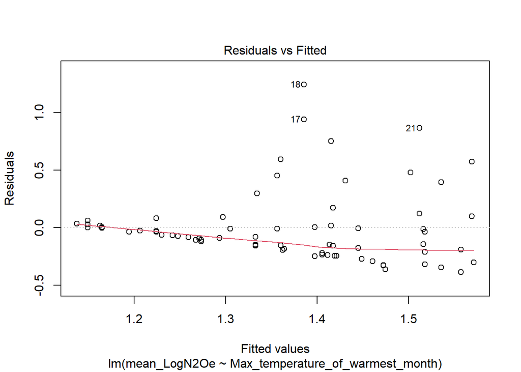

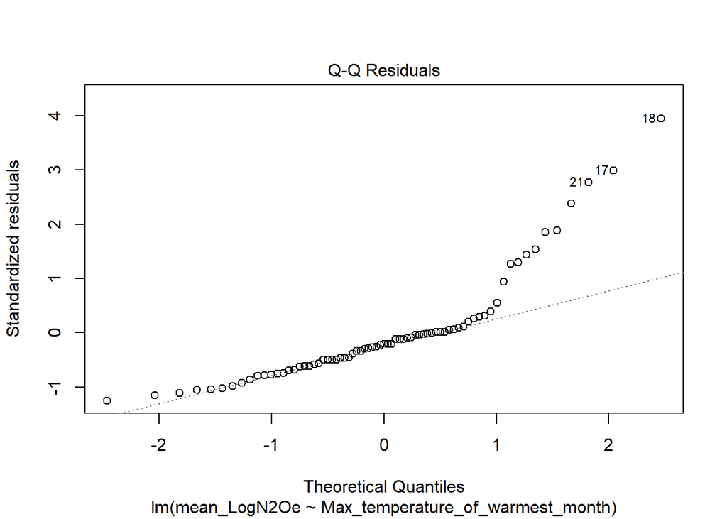

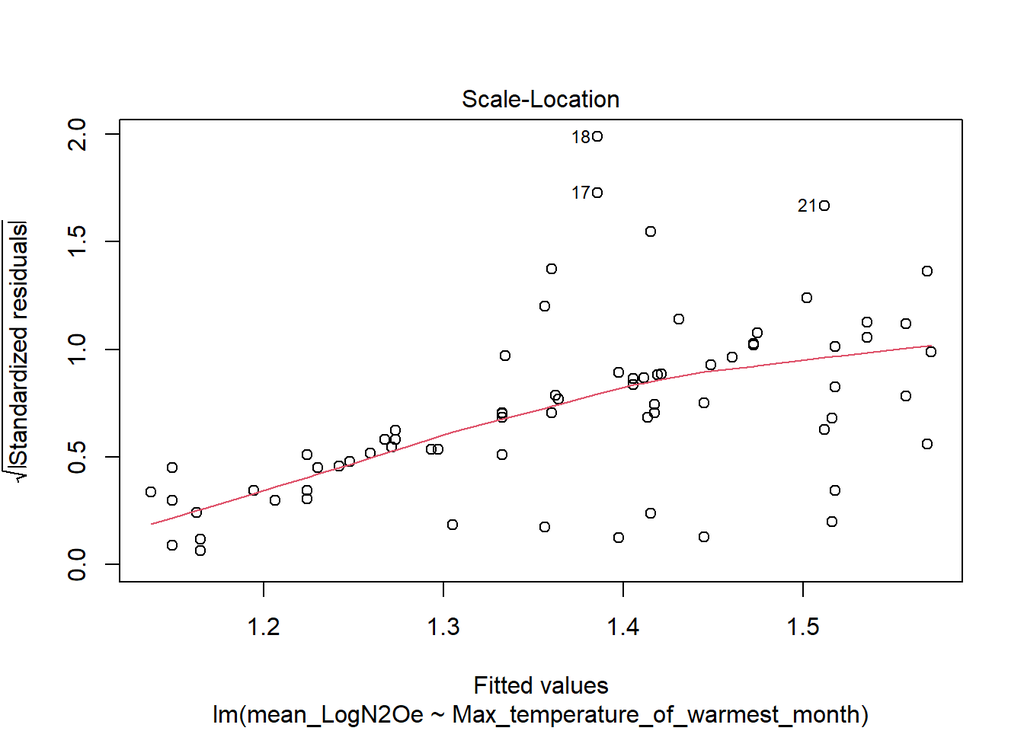

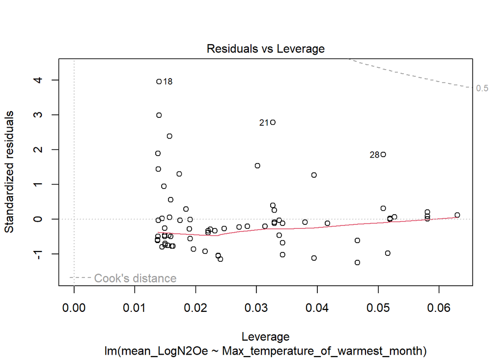

```r
plot(data_1v4)
```